# Final report

Chia-Hung, Liu (Eric)

2022/1/11

```r
library(readxl)
library(dplyr)
library(tidyverse)
library(sp)
library(rgdal)
```

#### 1. Introduction

Amphioxus belongs to Cephalochordate, which is thought to be an important transition taxon of invertebrates evolving to vertebrates. They are model species in evolutionary biology that can help us understand more about neurodevelopment. There are three genera of amphioxus, which are *Asymmetron*, *Epigonichthys*, and *Branchiostoma*. (Poss S. G, et al., 1996; Nishikawa T., 2004). Taiwan is recorded with five species, which is *A. lucayanum*, *E. maldivensis*, *E. cultellus*, *B. belcheri*, *B. japonicum* (Lin et al., 2015). The dominant species in Taiwan is *A. lucayanum*. However, due to pollution and human activity, the number of amphioxi decreases sharply. Many research resources are being put into knowing their reproduction patterns. Most *Branchiostoma* species can reproduce steadily in artificial environment. In contrast, we still know little about the reproduction of *Asymmetron*. The reproduction patterns of *A. lucayanum* in Taiwan can be divided into northern group and southern group by seasonal variations. Southern group has higher densities, and their amount reaches peak in June. Mature individuals can be found all over the year, showing no apparent breeding season. On the contrary, northern group has less densities, and their amount reaches peak in June as well. Mature individuals appear only from August to September. Therefore, temperature is supposed to be a key factor influencing the maturation of *A. lucayanum* in Taiwan (Lin et al., 2015).

#### 2. Aim

To realize the growth and reproduction pattern of *A. lucayanum* in Xialiuqiu, I proposed the following hypothesis:  
– Body length varied among different seasons or sites because different environmental conditions influence the growth of amphioxi.  
– Gonad index is correlated with body length. If amphioxus body length is larger, the gonad index should increase as well.  
– According to the survey conducted by Lin et al(2015), breeding season for southern groups of *A. lucayanum* is summer. The gonad index of amphioxi caught in summer should be larger than the ones caught in spring.

#### 3. Material & Method

Amphioxi were collected by scuba diving in August 2020(summer) and March 2021(spring). In the first sampling event, we collected amphioxi only in Lobster cave. In the second sampling event, We chose three sites, which were Lobster cave, Dafu, and Shanfu(figure1). After selected suitable sands in the depth from 5 to 17 meters, we dug the sands with sampling bags. The sands were brought back to the shore and put into a bucket. By stirring the sands, we could find out amphioxi hiding in the sands. The amphioxi were then scooped up by a spoon and poured into tubes.

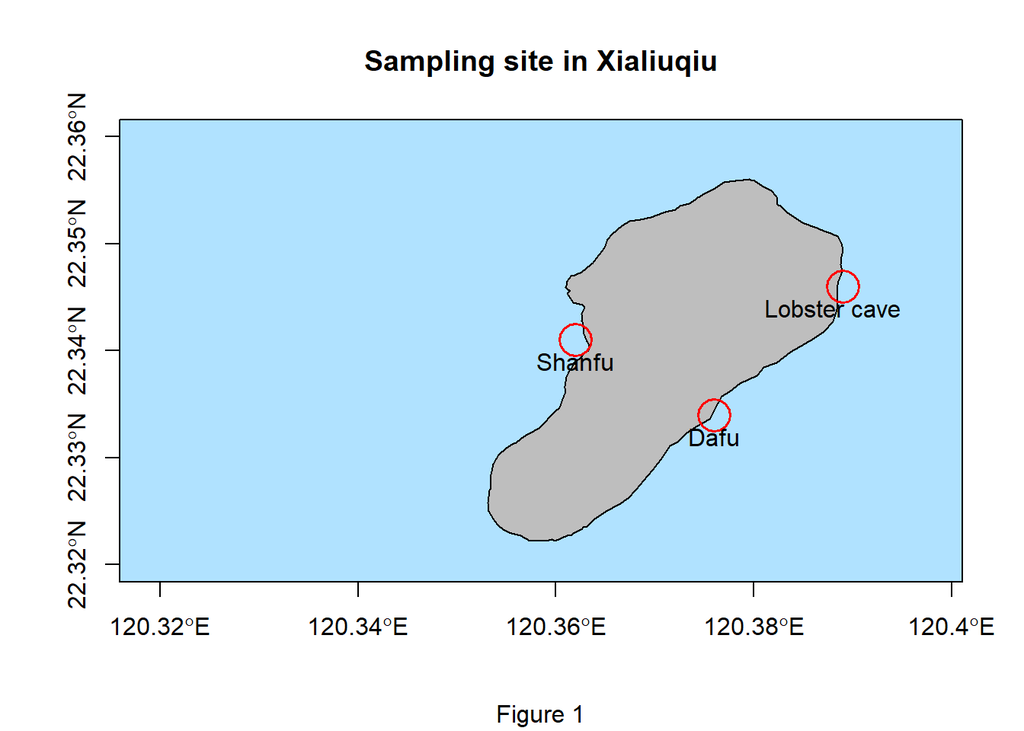

```r
# Mapping
# Get GIS data from the internet
url <- 'https://data.moi.gov.tw/MoiOD/System/DownloadFile.aspx?DATA=72874C55-884D-4CEA-B7D6-F60B0BE85AB0'
path1 <- tempfile(fileext = ".zip")
if (file.exists(path1))  'file alredy exists' else download.file(url, path1, mode="wb")
unzip(zipfile = path1,exdir = 'Data')

taiwan <- readOGR('Data/COUNTY_MOI_1090820.shp', use_iconv=TRUE, encoding='UTF-8')

# Plot xialiqiu map
plot(taiwan, axes = T, bg = colors()[431], col = 'grey', xlim = c(120.358, 120.359), ylim = c(22.32,22.36), main = 'Sampling site in Xialiuqiu', sub = 'Figure 1')

# Defining the positions of the sampling sites
coords <- matrix(cbind(lon = c(120.389,120.376,120.362),
                       lat = c(22.346,22.334,22.341)), ncol = 2)
coords <- coordinates(coords)
spoints <- SpatialPoints(coords)
location <- data.frame(location=c("Lobster cave","Dafu","Shanfu"))
spointsdf <- SpatialPointsDataFrame(spoints,location)
plot(spointsdf, add = TRUE,col='red', pch=1, cex = 3, lwd = 1.5)
text(120.388, 22.346-0.002,'Lobster cave')
text(120.376, 22.334-0.002,'Dafu')
text(120.362, 22.341-0.002,'Shanfu')
```

Amphioxi were brought back to the lab the next day to identify their species and measure their physical index,body length(BL), body height(BH), and gonad height(GH), under microscopes. Body length was measured along their notochords. Body height and gonad height were the maximum width of lancelet body and gonad, respectively. Gonad index is calculated as gonad height divided by body height(figure2). It can be used to represent relative ripeness(Holland, N. D., 2011).

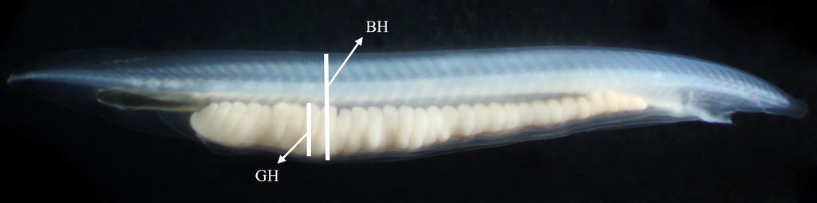

**Figure 2.** BH: body height; GH: gonad height

##### 4. Result

##### Data importation and arrangement

First, import the xlsx files and rearrange the data. Because the original data included another amphioxus species, *E. maldivensis*, I picked up the target species by `filter`. To combine the two table, I labeled each other with their sampling season and used `rbind` to combine them together.

```r
# Import data
Lan_summer <- read_excel('2020.8.18 lancelets.xlsx', sheet = 2)
Lan_spring <- read_excel('2021.03.14 lancelets.xlsx', sheet = 2)
# Filter target species
AL_summer <- Lan_summer %>%
  filter(Species == 'AL')
AL_spring <- Lan_spring %>%
  filter(Species == 'AL')
# Label with season
AL_summer <- AL_summer %>%
  mutate(Season = rep('Summer', length(AL_summer[ ,1])))
AL_spring <- AL_spring %>%
  mutate(Season = rep('Spring', length(AL_spring[ ,1])))
# Integration of summer and spring data
AL_total <- rbind(AL_summer, AL_spring)
# Transform Location, Species, and Season into factors
AL_total$Location <- as.factor(AL_total$Location)
AL_total$Species <- as.factor(AL_total$Species)
AL_total$Season <- as.factor(AL_total$Season)
# Check
head(AL_total)
```

```
## # A tibble: 6 x 9
##   Location      Site No           Species    BL    BH    GH    GI Season
##   <fct>        <dbl> <chr>        <fct>   <dbl> <dbl> <dbl> <dbl> <fct>
## 1 Lobster cave     1 20200810-1-1 AL       5.17 0.715 0     0     Summer
## 2 Lobster cave     1 20200818-1-1 AL       9.43 0.910 0     0     Summer
## 3 Lobster cave     1 20200818-1-2 AL      17.8  1.70  0.561 0.330 Summer
## 4 Lobster cave     1 20200818-1-3 AL      20.6  1.98  0.362 0.182 Summer
## 5 Lobster cave     1 20200818-1-4 AL       9.36 0.832 0.486 0.584 Summer
## 6 Lobster cave     2 20200818-2-1 AL      15.3  1.53  0     0     Summer
```

```r
str(AL_total)
```

```
## tibble [88 x 9] (S3: tbl_df/tbl/data.frame)
##  $ Location: Factor w/ 2 levels "Dafu","Lobster cave": 2 2 2 2 2 2 2 2 2 2 ...
##  $ Site    : num [1:88] 1 1 1 1 1 2 2 3 3 3 ...
##  $ No      : chr [1:88] "20200810-1-1" "20200818-1-1" "20200818-1-2" "20200818-1-3" ...
##  $ Species : Factor w/ 1 level "AL": 1 1 1 1 1 1 1 1 1 1 ...
##  $ BL      : num [1:88] 5.17 9.43 17.84 20.63 9.36 ...
##  $ BH      : num [1:88] 0.715 0.91 1.698 1.984 0.832 ...
##  $ GH      : num [1:88] 0 0 0.561 0.362 0.486 ...
##  $ GI      : num [1:88] 0 0 0.33 0.182 0.584 ...
##  $ Season  : Factor w/ 2 levels "Spring","Summer": 2 2 2 2 2 2 2 2 2 2 ...
```

##### Body length variations between spring and summer

To visualize the body length, I combined violin plot, jitter plot, and boxplot to present data variations, and it can show if body length are normal distributions at the same time.

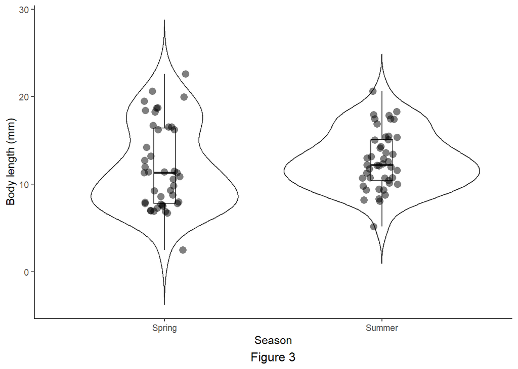

```r
season.p <- ggplot(AL_total, aes(x = Season, y = BL)) +
  geom_violin(trim = F) +
  geom_boxplot(width = 0.1)+
  geom_jitter(shape = 16, position = position_jitter(0.1),
              size = 3, alpha = 0.5)+
  ylab('Body length (mm)')+
  theme_classic()
season.p+labs(caption = 'Figure 3')+
  theme(plot.caption = element_text(hjust = 0.5, size = 12))
```

```r
shapiro.test(AL_spring$BL) # Not normal distributed
```

```
##
##  Shapiro-Wilk normality test
##
## data:  AL_spring$BL
## W = 0.92901, p-value = 0.01075
```

```r
shapiro.test(AL_summer$BL) # Normal distributed
```

```
##
##  Shapiro-Wilk normality test
##
## data:  AL_summer$BL
## W = 0.97867, p-value = 0.5667
```

```r
wilcox.test(AL_spring$BL, AL_summer$BL) # No significant difference
```

```
##
##  Wilcoxon rank sum test with continuity correction
##
## data:  AL_spring$BL and AL_summer$BL
## W = 796, p-value = 0.1535
## alternative hypothesis: true location shift is not equal to 0
```

##### Body length variations in Dafu and Lobster cave

I used the same way to visualize the data. Noted that because there were no *A. lucayanum* collected in Shanfu, there are only two location in the plot.

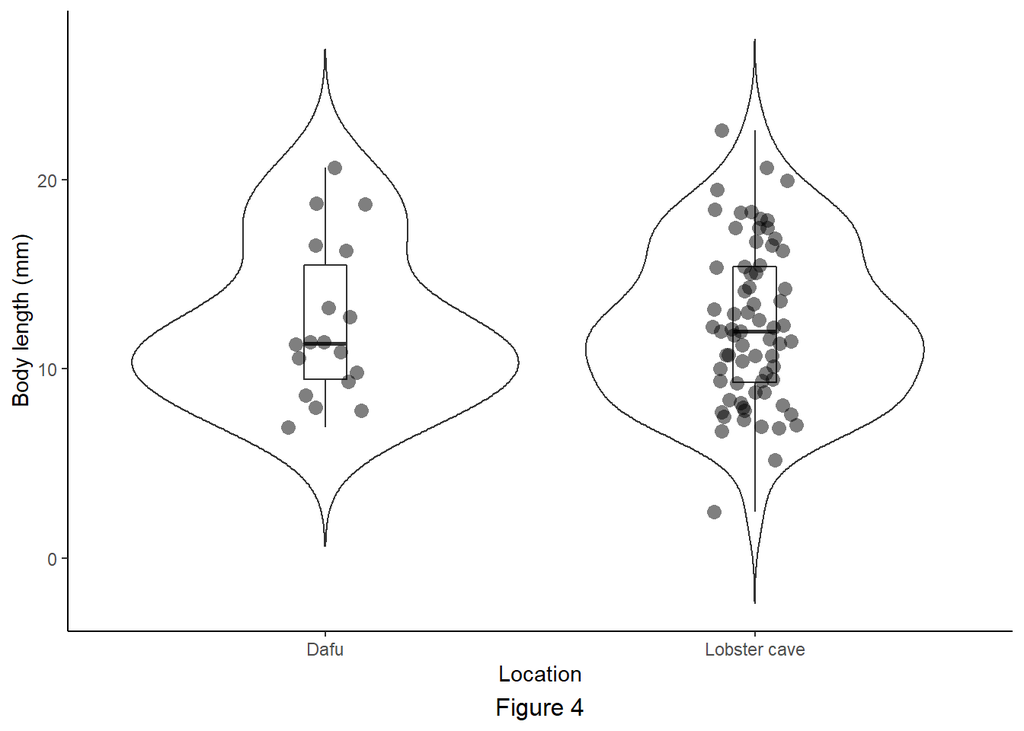

```r
location.p <- ggplot(AL_total, aes(x = Location, y = BL)) +
  geom_violin(trim = F) +
  geom_boxplot(width = 0.1)+
  geom_jitter(shape = 16, position = position_jitter(0.1),
              size = 3, alpha = 0.5)+
  ylab('Body length (mm)')+
  theme_classic()
location.p+labs(caption = 'Figure 4')+
  theme(plot.caption = element_text(hjust = 0.5, size = 12))
```

```r
#Location indices
LH <- which(AL_total$Location == 'Lobster cave')
DF <- which(AL_total$Location == 'Dafu')

shapiro.test(AL_total$BL[LH]) # Normal distributed
```

```
##
##  Shapiro-Wilk normality test
##
## data:  AL_total$BL[LH]
## W = 0.9815, p-value = 0.3887
```

```r
shapiro.test(AL_total$BL[DF]) # Normal distributed
```

```
##
##  Shapiro-Wilk normality test
##
## data:  AL_total$BL[DF]
## W = 0.91648, p-value = 0.112
```

```r
fligner.test (BL~Location, data = AL_total) # Equal variance
```

```
##
##  Fligner-Killeen test of homogeneity of variances
##
## data:  BL by Location
## Fligner-Killeen:med chi-squared = 0.14115, df = 1, p-value = 0.7071
```

```r
t.test(BL~Location, data = AL_total, var.equal = TRUE) # No significant difference
```

```
##
##  Two Sample t-test
##
## data:  BL by Location
## t = 0.031645, df = 86, p-value = 0.9748
## alternative hypothesis: true difference in means between group Dafu and group Lobster cave is not equal to 0
## 95 percent confidence interval:
##  -2.158964  2.228811
## sample estimates:
##         mean in group Dafu mean in group Lobster cave
##                   12.37555                   12.34062
```

#### Relationship between body length and gonad index

To know the relationship between body length and gonad index, I plotted a scatter plot and used different color to represent spring and summer samples.

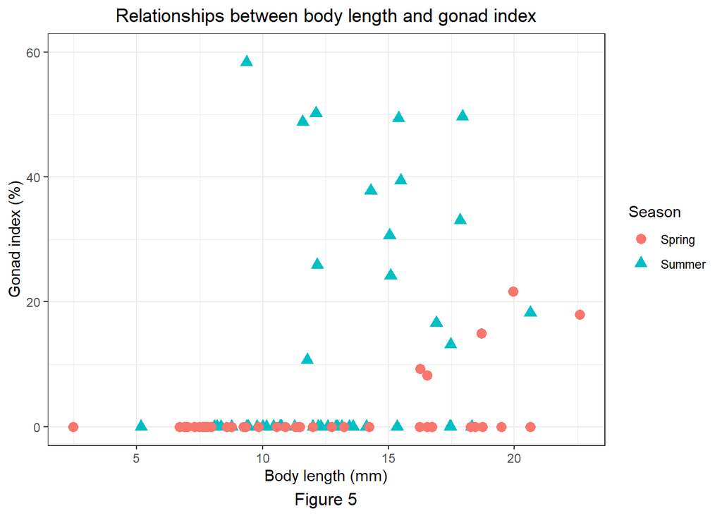

```r
BL_GI <- ggplot(data = AL_total, aes(x = BL, y = GI*100,
                            shape = Season, col = Season))+
  geom_point(size = 3) +
  ylim(c(0, 60))+
  xlab('Body length (mm)')+
  ylab('Gonad index (%)')+
  ggtitle('Relationships between body length and gonad index')+
  theme_bw()+
  theme(plot.title = element_text(hjust = 0.5))
BL_GI+labs(caption = 'Figure 5')+
  theme(plot.caption = element_text(hjust = 0.5, size = 12))
```

Build linear models to check whether gonad index of summer group and spring group have linear relationships with body length.

```r
lm_summer <- lm(GI ~ BL, data = AL_summer)
summary(lm_summer)
```

```
##
## Call:
## lm(formula = GI ~ BL, data = AL_summer)
##
## Residuals:
##      Min       1Q   Median       3Q      Max
## -0.20657 -0.10544 -0.06343  0.01512  0.52818
##
## Coefficients:
##              Estimate Std. Error t value Pr(>|t|)
## (Intercept) -0.102345   0.104716  -0.977   0.3339
## BL           0.016881   0.007966   2.119   0.0399 *
## ---
## Signif. codes:  0 '***' 0.001 '**' 0.01 '*' 0.05 '.' 0.1 ' ' 1
##
## Residual standard error: 0.1759 on 43 degrees of freedom
## Multiple R-squared:  0.09457,    Adjusted R-squared:  0.07351
## F-statistic: 4.491 on 1 and 43 DF,  p-value: 0.03989
```

```r
lm_spring <- lm(GI ~ BL, data = AL_spring)
summary(lm_spring)
```

```
##
## Call:
## lm(formula = GI ~ BL, data = AL_spring)
##
## Residuals:
##       Min        1Q    Median        3Q       Max
## -0.063897 -0.019000 -0.002039  0.009283  0.156267
##
## Coefficients:
##              Estimate Std. Error t value Pr(>|t|)
## (Intercept) -0.048169   0.017471  -2.757 0.008667 **
## BL           0.005432   0.001356   4.007 0.000253 ***
## ---
## Signif. codes:  0 '***' 0.001 '**' 0.01 '*' 0.05 '.' 0.1 ' ' 1
##
## Residual standard error: 0.04285 on 41 degrees of freedom
## Multiple R-squared:  0.2814, Adjusted R-squared:  0.2639
## F-statistic: 16.06 on 1 and 41 DF,  p-value: 0.0002531
```

#### 7. Reference

[1] Holland, N. D. (2011). Spawning periodicity of the lancelet, *Asymmetron lucayanum* (Cephalochordata), in Bimini, Bahamas. Italian Journal of Zoology, 78(4), 478-486.  
[2] Lin H. C., Chen J. P, Chan B. K. K., Shao K. T. (2015) The interplay of sediment characteristics, depth, water temperature, and ocean currents shaping the biogeo-graphy of lancelets (Subphylum Cephalochordata) in the NW Pacific waters. Marine Ecology 36: 780-793.  
[3] Nishikawa T. (2004) A New Deep-water Lancelet (Cephalochordata) from off Cape Nomamisaki, SW Japan, with a Proposal of the Revised System Recovering the Genus *Asymmetron*. Zoological Science 21: 1131-1136.  
[4] Poss S. G., Boschung H. T. (1996) Lancelets (Cephalochordata: Branchiostomatidae): How many species are valid? Israel Journal of Zoology, 42, S-13-S-66.